# (Ford GoBike System Analysis )

## by (Eman Abdelhalim)

## Investigation Overview

> In this investigation I wanted to find answers for my questions which are :
> - Top 5 stations with the most starts ?
> - Most popular trips (based on start station and stop station)
> - when are most trips taken in terms of time of day or day of week?
> - Most popular trips based on average duration (second).
> - Does the average trip duration depend on if a user is a subscriber or customer?

> So the main focus was on 8 features of rides (duration_sec, start_time, end_time, start_station_name,end_station_name, bike_id, user_type, member_gender)

## Dataset Overview

> This data set includes information about individual rides made in a bike-sharing system covering the greater San Francisco Bay area and the data consistwd of 16 features and attributes of approximately 183412 rides, the attributes included duration second of rides and time that trips started and ended in it aslo stations name ,user and gender types. 8265 data points were removed from the analysis due to inconsistencies or missing information.

## (Distribution of duration by seconds for rides)

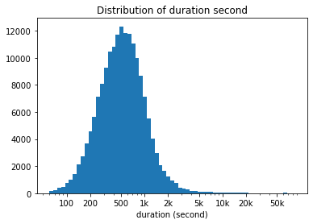

## 1- Top 5 stations

> we can see top station with most starts is : Market St at 10th St (3649 times of start)

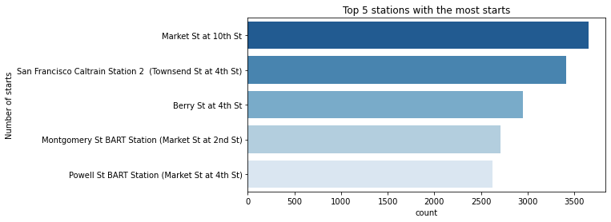

## 2- Most popular trips (based on start station and stop station)

> as we can see Most popular trips by number of trips is:Berry St at 4th St & San Francisco Ferry Building (327 trips)

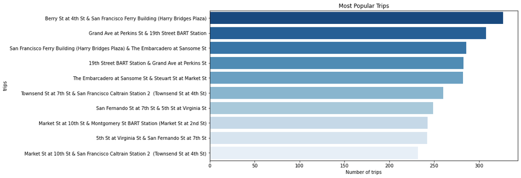

## 3- Most popular times of day trips started in it

> as we can see the most popular times of the day trips starts in are : 5 PM, 8AM, 6PM, 9AM, 4PM. so most customers and subscribers prefer to use bikes in the earlier times of morning and afternoon times.

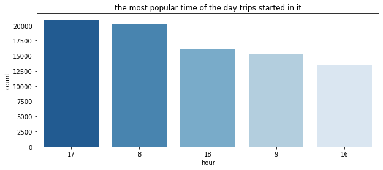

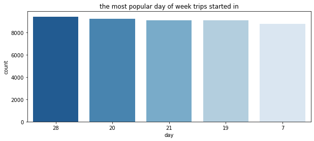

> Most popular trips by seconed used is : Fell St at Stanyan St & Fell St at Stanyan St (390598 seconds used)

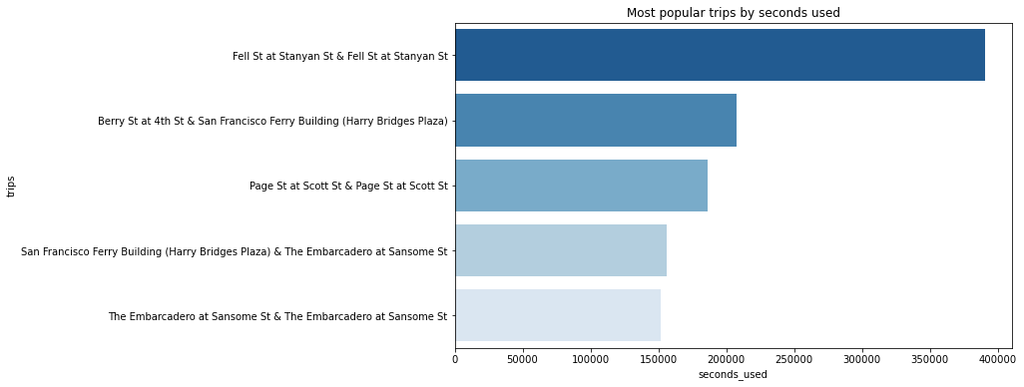

## 6- Average trip duration based on user type.

> as we can see it looks the customers using bikes longer than the subscribers despite of number of customer users less than subscriber users

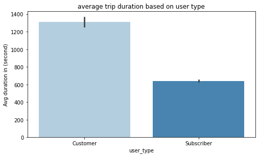

## 7- Average trip duration (based on the user type and gender type).

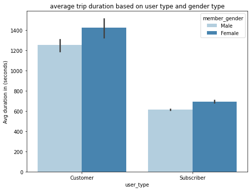